# Chapter 6: Further Inference in Multiple Regression

Andy’s next decision: evidence, models and new data

Eirik Eriksen Heen

# Session 1: What do the data support?

## Andy has two different questions

**Evidence:** Does advertising help explain sales once we control for price?

**Prediction:** Which model should Andy use to predict sales in another similar city?

We will use the same 75 cities as in Chapter 5.

R script · START UP and Part 1 | Textbook §§6.1, 6.4

## What we will be able to do

- Formulate and interpret a joint test using restricted and unrestricted models.
- Explain why model choice depends on the economic question.
- Evaluate predictions on held-out observations and assess the limits of one split.

**During the lecture:** predict, run the relevant R section, then explain the result.

## Back to the advertising curve

$$E(SALES\mid PRICE,A)=\beta_1+\beta_2PRICE+\beta_3A+\beta_4A^2.$$

```r
quadratic_model <- lm(sales ~ price + advert + I(advert^2),
                      data = andy)
```

**Recall:** What is the effect of another advertising dollar when advertising is already $A$?

R script · Part 1: The quadratic model | §6.1, Example 6.1

## The coefficients answer different questions

Table 1: Quadratic model, all 75 cities

| Term | Estimate | SE |
| --- | --- | --- |
| (Intercept) | 109.719 | 6.799 |
| price | -7.640 | 1.046 |
| advert | 12.151 | 3.556 |
| I(advert^2) | -2.768 | 0.941 |

Testing $\beta_3=0$ asks about the marginal effect **at $A=0$**.

Does that test answer whether advertising matters anywhere along the curve?

R script · Part 1: summary(quadratic_model)

## Advertising has no effect in this model if…

$$H_0:\beta_3=0\quad\text{and}\quad\beta_4=0.$$

$$H_1:\text{at least one of these restrictions is false.}$$

There are **two restrictions**, tested together.

**Predict:** What happens to fit when we force both coefficients to zero?

R script · Part 2: The joint hypothesis | §6.1

## Restricted and unrestricted models

**Unrestricted:** estimate the full advertising curve.

$$SALES=\beta_1+\beta_2PRICE+\beta_3A+\beta_4A^2+e.$$

**Restricted:** impose the joint null.

$$SALES=\beta_1+\beta_2PRICE+e.$$

```r
restricted_model <- lm(sales ~ price, data = andy)
```

R script · Part 2: Fit the restricted model

## How much fit do the restrictions cost?

Table 2: Same observations and outcome in both models

| Model | SSE | Parameters |
| --- | --- | --- |
| Restricted: price only | 1896 | 2 |
| Unrestricted: quadratic | 1532 | 4 |

Adding regressors cannot increase the OLS residual sum of squares.

**The question:** Is the reduction large relative to the noise?

R script · Part 2: SSE_R and SSE_U | §6.1

## The F-statistic compares loss of fit with noise

$$F=\frac{(SSE_R-SSE_U)/J}{SSE_U/(N-K)}.$$

- $J=2$: restrictions being tested.
- $N=75$, $K=4$: observations and unrestricted coefficients, including the intercept.
- Numerator: loss of fit per restriction. Denominator: estimated error variance.

Under $H_0$ and MR1–MR6: $F\sim F_{2,71}$.

R script · Part 2: Calculate F | §6.1, Example 6.2

## Calculate, then check with R

```r
F_advert <- ((SSE_R - SSE_U) / J) / (SSE_U / (N - K))
pf(F_advert, J, N - K, lower.tail = FALSE)
anova(restricted_model, quadratic_model)
```

$F=8.441$, with $p<0.001$.

At 5%, we reject the joint null: the advertising terms **jointly improve fit**.

R script · Part 2: Manual test and anova()

## What does the overall F-test test?

$$H_0:\beta_2=\beta_3=\beta_4=0.$$

The restricted model predicts the same mean sales for every city.

```r
intercept_model <- lm(sales ~ 1, data = andy)
anova(intercept_model, quadratic_model)
```

**Question:** Does a significant overall test tell Andy which variable matters?

R script · Part 3: Overall significance | §6.1.1

## One restriction: F and t agree

To test curvature: $H_0:\beta_4=0$ against $H_1:\beta_4\ne0$.

```r
anova(linear_model, quadratic_model)
t_squared_term^2
```

$F=8.659=t^2$; both tests give the same two-sided p-value.

The F-statistic loses the sign. Use a t-test for a directional alternative.

R script · Part 3: Compare F with t² | §6.1.2

## Two coefficients can form one restriction

At advertising of 1,900 dollars, marginal revenue is

$$\beta_3+2\beta_4(1.9)=\beta_3+3.8\beta_4.$$

Test whether this equals one dollar per extra advertising dollar:

$$H_0:\beta_3+3.8\beta_4=1.$$

**How many restrictions?** One. We can use a t-test.

R script · Part 4: A general restriction | §6.1.3, Example 6.5

## Return to the economic claim

```r
t_1900 <- (effect_1900 - 1) / effect_se
2 * pt(-abs(t_1900), df = N - K)
```

Estimated marginal revenue: **1.633 dollars per advertising dollar**.

$t=0.968$, $p=0.337$: do not reject equality at 5%.

This is compatible with the data. It does not prove that 1,900 dollars maximises profit.

R script · Part 4: The covariance calculation and test

## Which variables belong in Andy’s model?

**For a causal question:** Which variables must we account for to isolate an effect?

**For a prediction question:** Which available variables help predict another city’s sales?

A good answer to one question may be a poor answer to the other.

R script · Part 5: Model specification | §§6.3.1–6.3.5

## Omitting a variable can change an estimate

Suppose advertising affects sales and is correlated with price.

The price-only model can attribute some of the advertising relationship to price.

Table 3: Price estimates under different specifications

| Model | Price_coefficient |
| --- | --- |
| Price only | -7.829 |
| Price + advertising | -7.908 |
| Quadratic advertising | -7.640 |

Changing the estimate signals sensitivity; it does not identify the true causal model.

R script · Part 5: Compare the price coefficients | §6.3.2

## More variables: what can go wrong?

An irrelevant regressor need not bias OLS under the maintained assumptions, but it can reduce precision.

Highly related regressors provide little independent information about their separate coefficients.

**For Andy:** $A$ and $A^2$ move together. An individual coefficient may be imprecise even when the advertising terms jointly matter.

R script · Part 5: VIF_advert | §§6.3.3, 6.5

## Before the break: two different tests of a model

**F-test:** Did restrictions cause a sufficiently large loss of fit, relative to estimated noise?

**Prediction assessment:** Can the fitted equation predict observations it did not use?

**Discuss:** Why might the model with the lowest SSE still predict poorly?

# Session 2: How well does the model travel?

## Which model would you send to a new city?

| Candidate | Advertising terms |
| --- | --- |
| Linear | $A$ |
| Quadratic | $A$, $A^2$ |
| Flexible | $A$, $A^2$, …, $A^6$ |

All three also include an intercept and price.

**Vote before running R:** Which will fit the known data best? Which will predict new observations best?

R script · Part 6: Fixed candidate models | §6.4.1

## A fairer prediction exercise

**Training observations:** estimate the model coefficients.

**Held-out observations:** assess predictions without re-estimating the model.

The book calls these held-out observations a **hold-out sample**.

The outcome for a held-out city must not help fit its prediction.

R script · Part 6: Train and test | §6.4.1

## Make one reproducible split

```r
set.seed(308106)
train_id <- sample(seq_len(nrow(andy)), size = 56)
train <- andy[train_id, ]
test <- andy[-train_id, ]
```

**56 training cities; 19 held-out cities.**

The seed lets us reproduce the comparison. It does not guarantee a representative split.

R script · Part 6: Create train and test

## Same sample, different roles

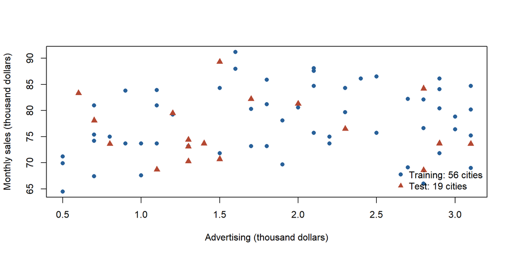

Figure 1

Price also enters every model; this plot shows only two dimensions.

R script · Part 6: split_plot()

## Fit on training data only

```r
train_linear <- lm(sales ~ price + advert, data = train)
train_quadratic <- lm(sales ~ price + advert + I(advert^2),
                      data = train)
train_flexible <- lm(sales ~ price + poly(advert, 6, raw = TRUE),
                     data = train)
```

**Check the argument:** `data = train` in all three models.

R script · Part 7: Estimate the three candidates

## Measure error in sales units

$$RMSE=\sqrt{\frac{1}{n}\sum_{i=1}^{n}(y_i-\widehat y_i)^2}.$$

```r
sqrt(mean(residuals(train_quadratic)^2))
```

Training RMSE: **4.368 thousand dollars**.

RMSE divides by the number of evaluated observations. It is different from the residual standard error, which uses $n-K$.

R script · Part 7: Training RMSE

## Predict a city that was left out

```r
prediction_quadratic <- predict(train_quadratic, newdata = test)
error_quadratic <- test$sales - prediction_quadratic
```

Table 4: First three held-out cities; sales in thousand dollars

[output not shown]

R script · Part 8: Predictions and errors

## Now reveal the test errors

```r
sqrt(mean((test$sales - prediction_quadratic)^2))
```

Table 5: One fixed 56/19 split; RMSE in thousand dollars

| Model | Training_RMSE | Test_RMSE |
| --- | --- | --- |
| Linear | 4.712 | 5.053 |
| Quadratic | 4.368 | 5.018 |
| Flexible | 4.329 | 4.879 |

**Which prediction did the evidence support on this split?**

R script · Part 8: Compare all three models

## Training fit and test performance

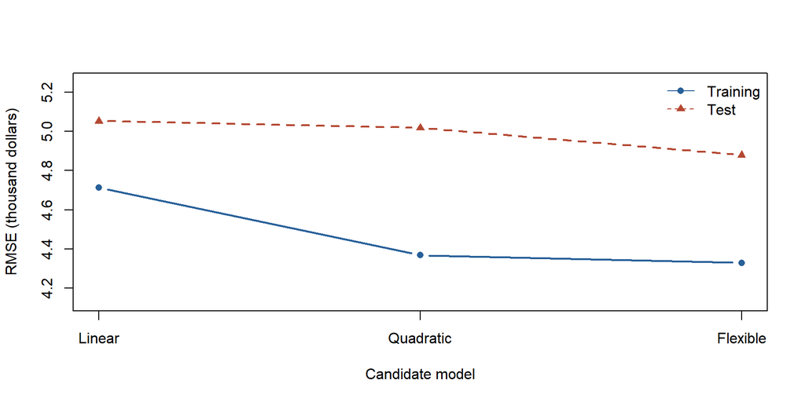

Figure 2

The flexible model wins **this split**. Greater flexibility can help, or it can overfit.

R script · Part 8: error_plot()

## A tempting mistake

> “The flexible model has the lowest error, so I will add more powers until its test RMSE is even lower.”

**Discuss:** What happens to the role of the test set as we keep using it to redesign the model?

R script · Part 8: Stop and interpret

## How much depends on the split?

Keep the **same three candidate formulas**.

Repeat the 56/19 division 200 times and assess held-out errors each time.

**Predict:** Will the same model always win?

```r
# Part 9 repeats: split -> fit on training -> predict held-out rows.
print(repeat_summary, row.names = FALSE)
```

R script · Part 9: Run the supplied loop

## A different winner across repeated splits

Table 6: 200 random splits of the same 75 cities

| Model | Median_RMSE | Wins |
| --- | --- | --- |
| Linear | 5.065 | 38 |
| Quadratic | 4.819 | 124 |
| Flexible | 5.084 | 38 |

The quadratic model wins most often; the first split favoured the flexible model.

**What recommendation can we defend now?**

R script · Part 9: Interpret the repeated comparisons

## The whole distribution matters

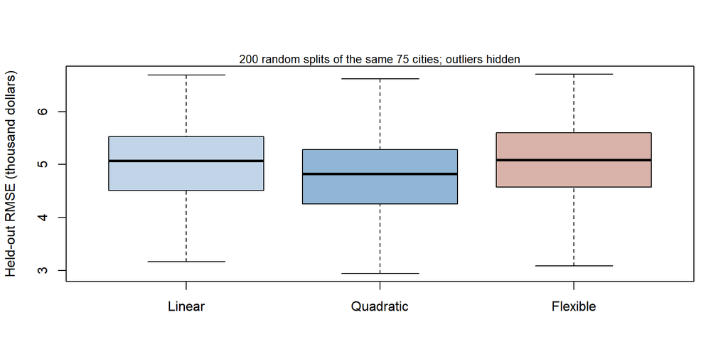

Figure 3

These are sensitivity results from one dataset, not a fresh final test sample.

R script · Part 9: repeat_plot()

## Other criteria penalise model complexity

Table 7: All criteria calculated on the same 56 training observations

| Model | Adjusted_R2 | AIC | BIC |
| --- | --- | --- | --- |
| Linear | 0.433 | 340.5 | 348.6 |
| Quadratic | 0.503 | 334.0 | 344.2 |
| Flexible | 0.471 | 341.0 | 359.3 |

Prefer higher adjusted $R^2$, or lower AIC/BIC, according to the chosen criterion.

These assess fit with a complexity penalty. Held-out RMSE assesses prediction on observations excluded from fitting.

R script · Part 10: Compare criteria | §6.4.1

## What would Andy need before using the model?

- Are new cities similar to the observed cities?
- Will price and advertising be known when making the prediction?
- How large is the prediction error in dollars, relative to the decision?
- How stable is the recommendation across reasonable specifications?

A random city split does not test forecasting future months or predicting a different market population.

R script · Part 10: Evidence and the decision

## Exit question

Andy adds four regressors. Training SSE falls, but held-out RMSE rises.

1. Has the model necessarily become more useful for prediction?
2. Does this demonstrate that the new regressors have no causal effects?
3. What should Andy examine before choosing the model?

# Reference and seminar material

## When fit improves but coefficients are imprecise

$$VIF_k=\frac{1}{1-R_k^2}.$$

$R_k^2$ comes from regressing $x_k$ on the other regressors.

```r
advert_auxiliary <- lm(advert ~ price + I(advert^2), data = andy)
1 / (1 - summary(advert_auxiliary)$r.squared)
```

High collinearity can reduce precision. Removing a needed variable can create a different problem.

R script · Review of Part 5 | §6.5

## What else is in Chapter 6?

| Section | Further reading |
| --- | --- |
| 6.1.5 | Large-sample tests and nonlinear hypotheses |
| 6.2 | Estimation using nonsample restrictions |
| 6.3.6 | RESET: evidence of specification problems |
| 6.4 | Uncertainty in individual predictions |
| 6.5.3 | Influential observations |
| 6.6 | Nonlinear least squares |

These topics are outside the main 90-minute lecture.

## Seminar: use the same workflow independently

**First block:** formulate restrictions, calculate F, and interpret the result.

**Second block:** compare predictive models, change the split proportion, and explain stability or instability in the recommendation.

Bring a conclusion in economic language, supported by the relevant output.

## Sources and companion resources

Hill, Griffiths and Lim, *Principles of Econometrics*, 5th edition, Chapter 6.

Main sections: **6.1, 6.3.1–6.3.5, 6.4.1**, with a short link to **6.5**.

Andy observations: textbook dataset, distributed in POE5Rdata.

Companion script: `S19_ch06_further_inference_mr.R`.

Keep the script and `data/andy.csv` together. All numerical slide results are calculated from that script.